# Machine Problem 2

Stat 142

Siegfred Roi L. Codia

October 15, 2025

# Instructions

- Use the `.Rmd` file as a template for your answer. Please change the author, the date, and file name. Use the format `Surname1_Surname2_Section` for your file name like this: `Codia1_Codia2_THW.html`.
- You will need to install and load a package called `rmdformats`.
- For each item in your machine problem, write your answer for that item below. Organize the way you put your answers by sectioning and hierarchies (the #s in the `.Rmd` file, although you can also use the visual editor).
- This is a open-notes machine problem to the extent of your own notes, our notes, `R` documentation (see the `Help` tab in `RStudio`), our references and the linked additional resources.
- Submit both the `.Rmd` and the knitted `.pdf` file at our `UVLe` page. I’ll primarily look at the latter, but the former helps me inspect them for debugging.
- For the references, you may add them at the end of your R notebook.
  - DO NOT USE AI.
  - You may only search how to do a specific part, but not the whole problem.
- For the file names, use the following format:
  - MP2_[groupnumber].rmd
  - MP2_[groupnumber].pdf
  - MP2_[groupnumber].html

# 1. A Simulation Study of Correlation Measures and Their Power

The strength of association between two variables can be assessed using different correlation measures:

- Pearson’s product-moment correlation ($\rho$) quantifies linear relationships, assuming finite variances and often used under normality assumptions.
- Spearman’s rank correlation ($\rho_s$) and Kendall’s coefficient ($\tau$) are nonparametric, rank-based measures of association that are more robust to outliers and non-normality.

The `cor.test` in R can be used to perform tests using these three measures.

Demonstrate empirically that the rank-based (nonparametric) tests using $\rho_s$ and $\tau$ are **less powerful than the Pearson correlation test** when samples are drawn from a **bivariate normal distribution**.

Then, provide an example of an alternative bivariate distribution, where $X$ and $Y$ are dependent, for which at least one of the nonparametric tests exhibits higher empirical power than the Pearson test.

# 2. A Bootstrap Confidence Interval for a Ratio

A researcher in a scientific foundation wished to evaluate the relation between intermediate and senior level annual salaries of research mathematicians ($Y$, in USD) and an index of publication quality ($X_1$), number of years of experience ($X_2$), and an index of success in obtaining grant support ($X_3$).

The data for a sample of 24 intermediate and senior level research mathematicians (Neter et al, 1989) is in the file `research.csv`.

| Y | 33.2 | 40.3 | 38.7 | 46.8 | 41.4 | 37.5 | 39.0 | 40.7 | 30.1 | 52.9 | 38.2 | 31.8 | 43.3 | 44.1 | 42.8 | 33.6 | 34.2 | 48 | 38 | 35.9 | 40.4 | 36.8 | 45.2 | 35.1 |
| --- | --- | --- | --- | --- | --- | --- | --- | --- | --- | --- | --- | --- | --- | --- | --- | --- | --- | --- | --- | --- | --- | --- | --- | --- |
| X1 | 3.5 | 5.3 | 5.1 | 5.8 | 4.2 | 6.0 | 6.8 | 5.5 | 3.1 | 7.2 | 4.5 | 4.9 | 8.0 | 6.5 | 6.6 | 3.7 | 6.2 | 7 | 4 | 4.5 | 5.9 | 5.6 | 4.8 | 3.9 |
| X2 | 9.0 | 20.0 | 18.0 | 33.0 | 31.0 | 13.0 | 25.0 | 30.0 | 5.0 | 47.0 | 25.0 | 11.0 | 23.0 | 35.0 | 39.0 | 21.0 | 7.0 | 40 | 35 | 23.0 | 33.0 | 27.0 | 34.0 | 15.0 |
| X3 | 6.1 | 6.4 | 7.4 | 6.7 | 7.5 | 5.9 | 6.0 | 4.0 | 5.8 | 8.3 | 5.0 | 6.4 | 7.6 | 7.0 | 5.0 | 4.4 | 5.5 | 7 | 6 | 3.5 | 4.9 | 4.3 | 8.0 | 5.0 |

The following multiple linear regression model is used to describe the relation:

$$Y_i = \beta_0 +\beta_1X_{i1} +\beta_32X_{i2}+ \beta_3X_{i3} +
\varepsilon_i$$

where $X_i$s are fixed. Let $\hat{\beta_j}$ be the OLS estimator of $\beta_j$, $j=0,1,2,3$.

1. Fit a linear regression model on the data using the `lm` function. Show the coefficients and interpret results.
2. The quantity $\beta_1/\beta_3$ is the ratio of the effects of the index of publication quality and index of success in obtaining granting support. If the ratio is equal to 1, it means the effects are equal.

   Suppose we estimate $\beta_1/\beta_3$ using $\hat{\beta_1}/\hat{\beta_3}$. Write down an algorithm that uses the bootstrap to compute a 95% percentile confidence interval for $\beta_1/\beta_3$.
3. Using $B=2000$ bootstrap samples, implement your procedure in (b) and provide the percentile confidence interval. Is 1 inside the confidence interval? What does this mean?

# 3. An Evaluation of Models using Cross-Validation

The `ironslag.csv` has 53 measurements of iron content by two methods, chemical and magnetic (Hand et.al, 1996). A scatterplot of the data suggests that the chemical and magnetic variables are positively correlated, but **the relation may not be linear**.

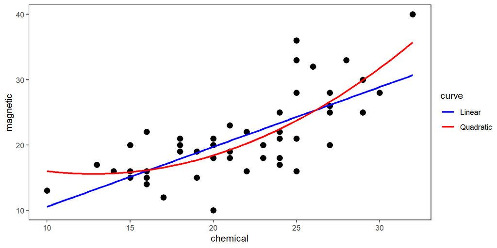

The proposed models for predicting magnetic measurement ($Y$) from chemical measurement ($X$) are:

1. Linear: $Y=\beta_0+\beta_1X+\varepsilon$
2. Quadratic: $Y=\beta_0+\beta_1X+ \beta_2X + \varepsilon$

Using 5-fold cross-validation, evaluate the prediction errors of the two proposed models.

# 4. An Extreme Value Distribution

The Gumbel distribution is one of the distributions that is used to model extreme values.

It has the following CDF, with location parameter $\mu\in\mathbb{R}$ and scale parameter $\sigma >0$ :

$$G(z) = \exp\left\{-\exp\left[
-\left(\frac{z-\mu}{\sigma}\right)\right]\right\}$$

Note: $\mu$ and $\sigma$ are NOT the population mean and standard deviation of this distribution.

**Task 1: Generate a dataset from** $G(z)$

Create a function that simulates values from Gumbel distribution for given parameters $\mu$ and $\sigma$. This should involve generating a data from $U(0,1)$ using `runif(n)` where `n` is the number of elements in the sample.

Apply this function to generate $Z_1,Z_2,...,Z_{50}\overset{iid}{\sim} Gumbel(\mu = 30, \sigma =10)$

**Task 2: Obtain maximum likelihood estimates of** $\mu$ **and** $\sigma$ **given a dataset.**

The log-likelihood for the parameters $\mu$ and $\sigma$ is given by

$$\ell(\boldsymbol{\theta}|z_i) =
-n\log\sigma-\sum_{i=1}^n\left(\frac{z_i-\mu}{\sigma}\right) -
\sum_{i=1}^n\exp\left\{-\left(\frac{z_i-\mu}{\sigma}\right)\right\}$$
where $\boldsymbol{\theta}=\begin{bmatrix}\mu\\ \sigma\end{bmatrix}$ is a vector of parameters, and $z_i$ are the observed values.

The gradient is given by:

$$\nabla\ell(\boldsymbol{\theta}) =
\begin{bmatrix}
\frac{\partial \ell(\mu,\beta)}{\partial\mu}\\
\frac{\partial \ell(\mu,\beta)}{\partial \sigma}
\end{bmatrix}=
\frac{1}{\sigma}
\begin{bmatrix}
\sum_{i=1}^n\left(1-\exp\left\{-\frac{z_i-\mu}{\sigma}\right\}\right)\\
\sum_{i=1}^n\left(-1+\frac{z_i-\mu}{\sigma}+\frac{z_i-\mu}{\sigma}\exp\left\{-\frac{z_i-\mu}{\sigma}\right\}\right)
\end{bmatrix}$$

and the Hessian matrix is given by:

$$\nabla^2 \ell(\boldsymbol{\theta}) =
\begin{bmatrix}
\frac{\partial^2 \ell(\mu,\beta)}{\partial\mu^2} &
\frac{\partial^2 \ell(\mu,\beta)}{\partial\sigma\partial\mu}\\
\frac{\partial^2 \ell(\mu,\beta)}{\partial\mu\partial\sigma}&
\frac{\partial^2 \ell(\mu,\beta)}{\partial \sigma^2}
\end{bmatrix} \\=
\frac{1}{\sigma^2}
\begin{bmatrix}
-\sum_{i=1}^n\exp(-z_i^*) &
-\sum_{i=1}^n(1-\exp(-z_i^*)-z_i^*\exp(-z_i^*))\\
-\sum_{i=1}^n(1-\exp(-z_i^*)-z_i^*\exp(-z_i^*)) &
\sum_{i=1}^n (1-2z_i^*+z_i^*(z_i^*-2)\exp(-z_i^*))
\end{bmatrix}$$

where $z_i^*=\frac{z_i-\mu}{\sigma}$

1. Create functions `gradient_loglik` and `hessian_loglik` that return the Gradient vector and Hessian matrix of $\ell(\boldsymbol{\theta})$ respectively. Both should take the following arguments:
   - `theta` - the parameter vector $[\mu,\sigma]'$
   - `z` - the data vector
2. Create function `fit_gumbel` that implements Newton’s method to obtain maximum likelihood estimates of $\mu$ and $\sigma$ given a data vector `z`. Use the `gradient_loglik` and `hessian_loglik` inside this function. Use the sample mean and standard deviation as initial values of $\mu$ and $\sigma$ respectively.
3. Apply the function `fit_gumbel` on the data generated in Task 1.